# New Simulation

Andrew Baker

2020-02-17

In this memo I do the simulation comparison requested by Professor David F. Larcker dated February 15, 2020. In particular, we will show two sets of DiD estimates - one the standard DiD estimates where treatment occurs in only one period, and a second where the treatment assignment is staggered. We will then show that while the former is an unbiased estimate of the average treatment effect using two-way fixed effects estimation, the latter is not.

As in the simulation in our draft, the data generating process is:

$$y_{it} = \alpha_i + \alpha_t + \tau_{it} + \epsilon_{it}$$

where $\alpha_i$ are unit fixed effects drawn from $\sim N(0, 1)$, $\alpha_t$ are period fixed effects, also drawn from $\sim N(0, 1)$, and the white-noise error term $\epsilon_{it}$ is drawn from $\sim N\left(0, \left(\frac{1}{2}\right)^2\right)$.

We will consider two different treatment assignment set ups for $\tau_{it}$. The first is the standard DiD with multiple units but where the treatment is initiated all in the same year. We assume that there are 40 states (40 makes the assignment mechanism easier here), and the 1000 units $i$ in are sample are randomly assigned to one of the 40 states. Of the 40 states, half are randomly selected to receive “treatment” in 1995 (the sample here is 1980 to 2010). For every unit incorporated in a treated state, we pull a unit-specific treatment effect from $\mu_i \sim N(0.3, (1/5)^2)$, and the cumulated treatment effect $\tau_{it}$ is $\mu_i \times (year - 1995 + 1)$ for years after 1995. We then estimate the average treatment effect as $\hat{\delta}$ from:

$$y_{it} = \hat{\alpha_i} + \hat{\alpha_t} + \hat{\delta} D_{it}$$

where $D_{it}$ is an indicator for being incorporated in a treated state for years greater than or equal to 1995. $\hat{\delta}$ should be an unbiased estimate of the average treatment effect. Because DiD with a binary treatment indicator variable captures the difference in the average post-treatment outcomes to the average pre-treatment outcomes, we can analytically derive the expected average treatment effect. There are 16 post-treatment periods, so the average treatment effect should be $\frac{16 + 1}{2} \times .3 \approx 2.5$.

Next, we will run a similar analysis using a “staggered” treatment design. Now the forty states are randomly assigned into four treatment cohorts of size 250 depending on the year of treatment assignment (1986, 1992, 1998, and 2004). The data-generating process is identical, except that now $\tau_{it}$ is equal to $\mu_i \times (year - \tau_g + 1)$ where $\tau_g$ is the treatment year for the state of incorporation. We can also analytically derive the average treatment effect under this treatment regime, which is close but not identical to above:

$$ATE = \frac{1}{4} \times .3 \times \left(\frac{2010 - 1986 + 1}{2} + \frac{2010 - 1992 + 1}{2} + \frac{2010 - 1998 + 1}{2} + \frac{2010 - 2004 + 1}{2} \right) = 2.4$$
We estimate the treatment effect using the same two-way fixed effects specification above, with $D_{it}$ being an indicator for being incorporated in a state on or after it’s treatment assignment year $\tau_g$.

Becuase this uses random number generation for the simulated effects, I run both sets of estimates 1000 times and plot the distribution of the treatment effects. The red line indicates the true treatment effects derived above.

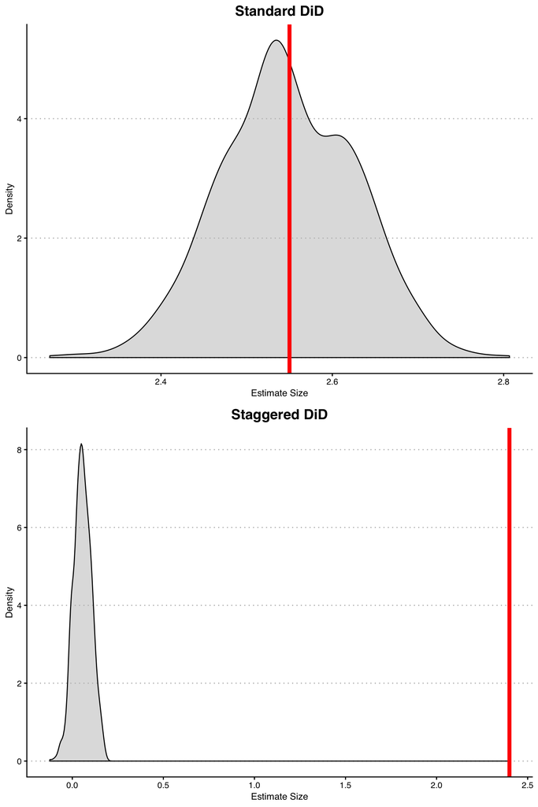

```r
library(tidyverse)
library(patchwork)
library(kableExtra)
library(lfe)
library(lmtest)
library(xtable)
library(did)
library(magrittr)
library(ggthemes)
library(bacondecomp)
library(did2)
library(multcomp)
select <- dplyr::select
theme_set(theme_clean() + theme(plot.background = element_blank()))

# Make Data  ---------------------------------------------
# loop function for one-time DiD shock
DID_onetime <- function(...) {

  # Fixed Effects ------------------------------------------------
  # unit fixed effects
  unit <- tibble(
    unit = 1:1000,
    unit_fe = rnorm(1000, 0, 1),
    # generate state
    state = sample(1:40, 1000, replace = TRUE),
    # generate treatment effect
    mu = rnorm(1000, 0.3, 0.2))

  # year fixed effects
  year <- tibble(
    year = 1980:2010,
    year_fe = rnorm(31, 0, 1))

  # Trend Break -------------------------------------------------------------
  # Put the states into treatment groups
  treat_taus <- tibble(
    # sample the states randomly
    state = sample(1:40, 40, replace = FALSE),
    # place the randomly sampled states into treatment and control states
    treated_unit = sample(c(rep(1, 20), rep(0, 20)), 40, replace = FALSE))

  # make main dataset
  # full interaction of unit X year
  data <- expand_grid(unit = 1:1000, year = 1980:2010) %>%
    left_join(., unit) %>%
    left_join(., year) %>%
    left_join(., treat_taus) %>%
    # make error term and get treatment indicators and treatment effects
    mutate(error = rnorm(31000, 0, 0.5),
           treat = ifelse(year >= 1995 & treated_unit == 1, 1, 0),
           tau = ifelse(treat == 1, mu, 0)) %>%
    # calculate cumulative treatment effects
    group_by(unit) %>%
    mutate(tau_cum = cumsum(tau)) %>%
    ungroup() %>%
    # calculate the dep variable
    mutate(dep_var = unit_fe + year_fe + tau_cum + error)

  # run the DID and get the treatment effect estimates
  broom::tidy(felm(dep_var ~ treat | unit + year | 0 | state, data = data,
                   exactDOF = TRUE, cmethod = "reghdfe"))
}

# estimate 1000 times
# set seed
set.seed(2140851)
DID_one_data <- map_dfr(1:1000, DID_onetime)

# plot DID estimates
plot1 <- DID_one_data %>%
  ggplot(aes(x = estimate)) + geom_density(fill = "gray", alpha = 1/2) +
  geom_vline(xintercept = 8.5*.3, color = "red", size = 2) +
  labs(x = "Estimate Size", y = "Density", title = "Standard DiD") +
  theme(plot.title = element_text(hjust = 0.5, size = 15))

## estimate DID model 2 - 250 firms are treated every period, with the treatment effect still = 0.3 on average
# loop function for one-time DiD shock
DID_multiple <- function(...) {

  # Fixed Effects ------------------------------------------------
  # unit fixed effects
  unit <- tibble(
    unit = 1:1000,
    unit_fe = rnorm(1000, 0, 1),
    # generate state
    state = sample(1:40, 1000, replace = TRUE),
    # generate treatment effect
    mu = rnorm(1000, 0.3, 0.2))

  # year fixed effects
  year <- tibble(
    year = 1980:2010,
    year_fe = rnorm(31, 0, 1))

  # Trend Break -------------------------------------------------------------
  # Put the states into treatment groups
  treat_taus <- tibble(
    # sample the states randomly
    state = sample(1:40, 40, replace = FALSE),
    # place the randomly sampled states into five treatment groups G_g
    cohort_year = sort(rep(c(1986, 1992, 1998, 2004), 10)))

  # make main dataset
  # full interaction of unit X year
  data <- expand_grid(unit = 1:1000, year = 1980:2010) %>%
    left_join(., unit) %>%
    left_join(., year) %>%
    left_join(., treat_taus) %>%
    # make error term and get treatment indicators and treatment effects
    mutate(error = rnorm(31000, 0, 0.5),
           treat = ifelse(year >= cohort_year, 1, 0),
           tau = ifelse(treat == 1, mu, 0)) %>%
    # calculate cumulative treatment effects
    group_by(unit) %>%
    mutate(tau_cum = cumsum(tau)) %>%
    ungroup() %>%
    # calculate the dep variable
    mutate(dep_var = unit_fe + year_fe + tau_cum + error)

  # run the DID and get the treatment effect estimates
  broom::tidy(felm(dep_var ~ treat | unit + year | 0 | state, data = data,
                   exactDOF = TRUE, cmethod = "reghdfe"))
}

# set seed
set.seed(2140851)
DID_multiple <- map_dfr(1:1000, DID_multiple)

# plot DID estimates
plot2 <- DID_multiple %>%
  ggplot(aes(x = estimate)) + geom_density(fill = "gray", alpha = 1/2) +
  geom_vline(xintercept = 2.4, color = "red", size = 2) +
  labs(x = "Estimate Size", y = "Density", title = "Staggered DiD") +
  theme(plot.title = element_text(hjust = 0.5, size = 15))

plot1 / plot2
```